# Trump, the US Stock Market, and Economics News

Analysing Headline Tones, Number of Trump Mentions and Movements in the S&P 500 in ASB’s Daily Alert Articles

“Ever wondered if the mood of the news offer a clue about stock market movements? Or if the number of times ‘Trump’ is mentioned shape the tone of the headlines. In all honestly probably not….But in any case this visual data story dive into ASB Daily Alert’ headlines — whether they’re upbeat, indifferent, or downright gloomy to see how they align with shifts in the US S&P 500 index and mention of our fave politician Donald J. Trump. *ASB’s Daily Alert are a daily snapshot of key domestic and global events that may impact foreign exchange and money markets.*

## Does the Tone of Economic News Headlines Indicate the Movements of the Stock Market?

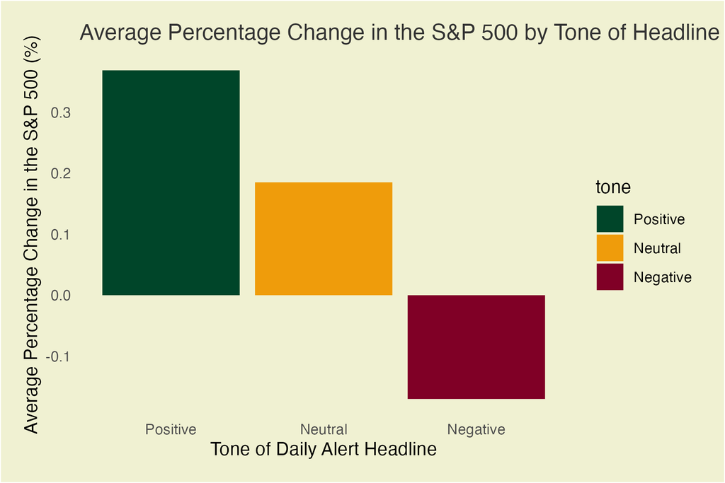

A bar chart showing that positive headlines coincide with the largest average increase in the S&P 500, whilst negative headlines coincide decreases on average

The data collected suggests a negative correlation between the number of trump mentions and the positivity of the daily alert headline. Positive headlines align with the largest average increase in the S&P 500, whilst negative headlines coincide decreases on average.

## Does the Frequency of Trump’s Name Indicate the Negativity of the Headline?

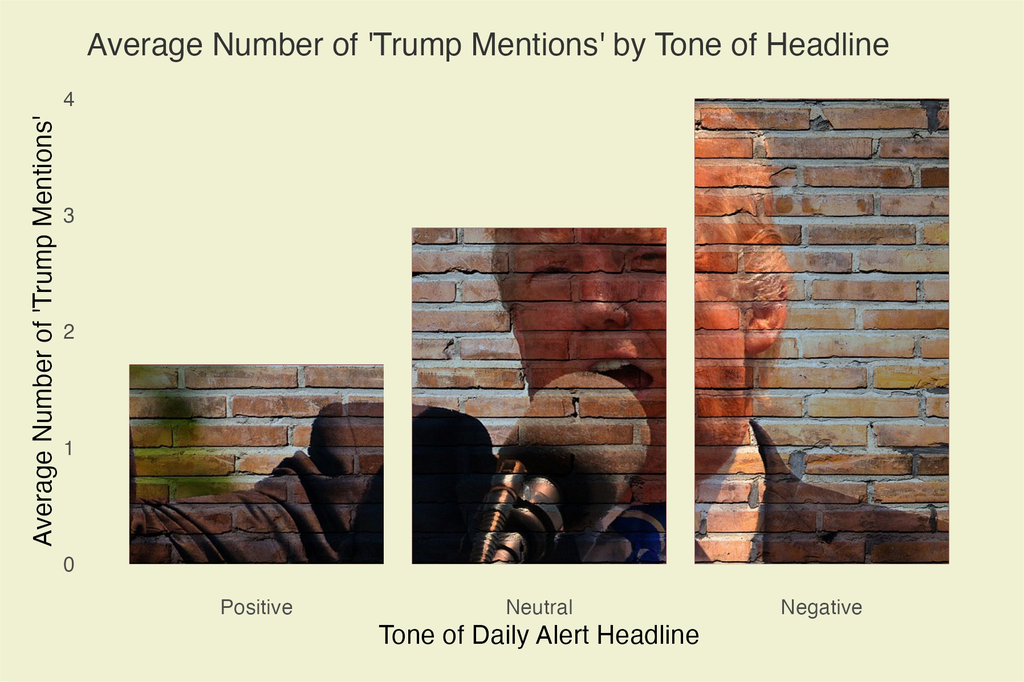

A bar chart styled with a Trump image showing that negative headlines mention Trump most often, while positive headlines mention him the least.

This striking visual highlights that alerts with negative headlines mention Trump more on average and those with positive headlines mentioned Trump the least. Who would have thought!?!

## The Stock Market; Is There Light at the End of the Tunnel?

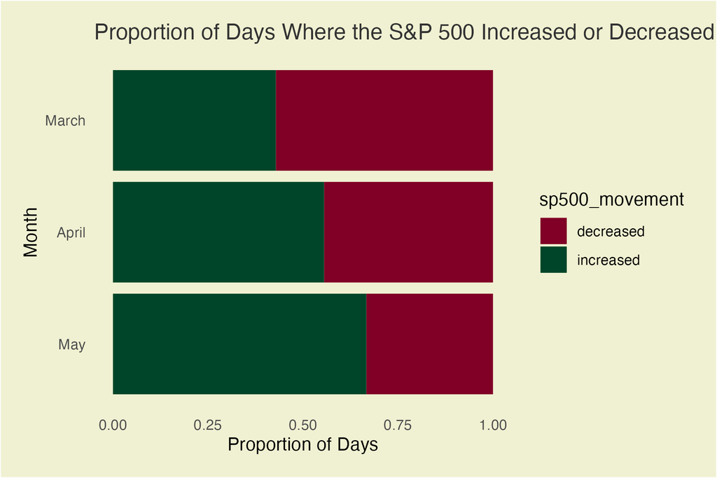

A horizontal stacked bar chart showing the proportion of days the S&P 500 increased or decreased in each month from March to May. May had the highest proportion of increases whilst March had the least.

It’s been rough for those in the stock market lately. But is there hope? The proportion of days in which the S&P 500 went up increased from March to April and from April to May (what data has been collected as of now). Thus it would appear all is not lost!

## Does the Day of the Week Have Any Impact on Stock Market Movement?

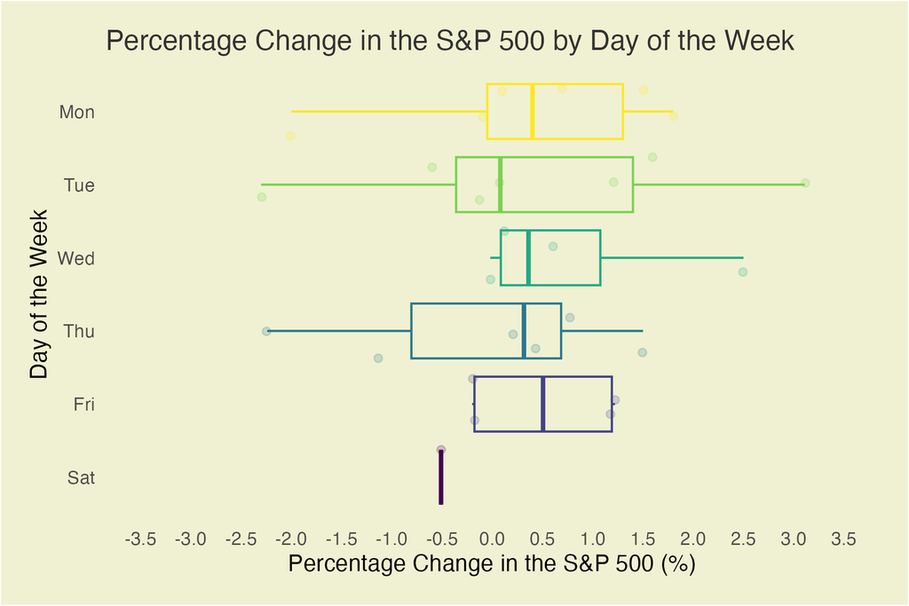